# Deriving reproducible biomarkers from multi-site resting-state data: An Autism-based example - ScienceDirect

- [View **PDF**](https://www.sciencedirect.com/science/article/pii/S1053811916305924/pdfft?md5=0d3e59ec16542bd4f81fbce69b6e6457&pid=1-s2.0-S1053811916305924-main.pdf)

## Outline

2. Abstract
4. Keywords
5. 1. Introduction
6. 2. Material and methods
7. 3. Results
8. 4. Discussion
9. Acknowledgments
10. Appendix A. Supplementary information
11. References

## Figures (7)

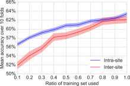

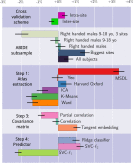

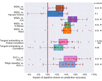

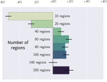

## Tables (2)

1. Table 1
2. Table 2

## Extras (1)

1. Supplementary Material

## [NeuroImage](https://www.sciencedirect.com/science/journal/10538119)

[Volume 147](https://www.sciencedirect.com/science/journal/10538119/147/supp/C), 15 February 2017, Pages 736-745

# Deriving reproducible biomarkers from multi-site resting-state data: An Autism-based example

[AlexandreAbraham<sup>a</sup><sup>b</sup>](https://www.sciencedirect.com/science/article/pii/S1053811916305924?via%3Dihub#!)[Michael P.Milham<sup>e</sup><sup>f</sup>](https://www.sciencedirect.com/science/article/pii/S1053811916305924?via%3Dihub#!)[AdrianaDi Martino<sup>g</sup>](https://www.sciencedirect.com/science/article/pii/S1053811916305924?via%3Dihub#!)[R. CameronCraddock<sup>e</sup><sup>f</sup>](https://www.sciencedirect.com/science/article/pii/S1053811916305924?via%3Dihub#!)[DimitrisSamaras<sup>c</sup><sup>d</sup>](https://www.sciencedirect.com/science/article/pii/S1053811916305924?via%3Dihub#!)[BertrandThirion<sup>a</sup><sup>b</sup>](https://www.sciencedirect.com/science/article/pii/S1053811916305924?via%3Dihub#!)[GaelVaroquaux<sup>a</sup><sup>b</sup>](https://www.sciencedirect.com/science/article/pii/S1053811916305924?via%3Dihub#!)

https://doi.org/10.1016/j.neuroimage.2016.10.045[Get rights and content](https://s100.copyright.com/AppDispatchServlet?publisherName=ELS&contentID=S1053811916305924&orderBeanReset=true)

### Highlights

**•**

We propose a fully-automatic pipeline to extract biomarkers from resting state fMRI.

**•**

We demonstrate prediction in a clinical setting, on subjects coming from unseen site.

**•**

A post-hoc analysis of the pipeline steps sketches an ideal pipeline for prediction.

**•**

Extracted autism biomarkers are stable across training sets and consistent with literature.

## Abstract

### Graphical abstract

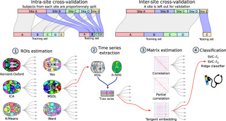

## Keywords

Data heterogeneity

Resting-state fMRI

Data pipelines

Biomarkers

Connectome

Autism spectrum disorders

## 1. Introduction

In psychiatry, as in other fields of medicine, both the standardized observation of signs, as well as the symptom profile are critical for diagnosis. However, compared to other fields of medicine, psychiatry lacks accompanying objective markers that could lead to more refined diagnoses and targeted treatment (Kapur et al., 2012). Advances in non-invasive [brain imaging](https://www.sciencedirect.com/topics/medicine-and-dentistry/brain-imaging) techniques and analyses (e.g. Craddock et al., 2013, Van Essen and Ugurbil, 2012) are showing great promise for uncovering patterns of brain structure and function that can be used as objective measures of [mental illness](https://www.sciencedirect.com/topics/neuroscience/psychopathology). Such *neurophenotypes* are important for clinical applications such as disease staging, determination of risk prognosis, prediction and monitoring of treatment response, and aid towards diagnosis (e.g. Castellanos et al. (2013)).

Among the many [imaging techniques](https://www.sciencedirect.com/topics/medicine-and-dentistry/imaging-technique) available, [resting-state fMRI](https://www.sciencedirect.com/topics/medicine-and-dentistry/resting-state-fmri) (R-fMRI) is a promising candidate to define functional neurophenotypes (Kelly et al., 2008, Van Essen and Ugurbil, 2012). In particular, it is non-invasive and, unlike conventional task-based fMRI, it does not require a constrained experimental setup nor the active and focused participation of the subject. It has been proven to capture interactions between brain regions that may lead to neuropathology diagnostic biomarkers (Greicius, 2008). Numerous studies have linked variations in brain functional architecture measured from R-fMRI to behavioral traits and mental health conditions such as Alzheimer disease (e.g. Greicius et al., 2004, Chen et al., 2011, [Schizophrenia](https://www.sciencedirect.com/topics/neuroscience/dementia-praecox) (e.g. Garrity et al.,, Zhou et al., 2007, Jafri et al., 2008, Calhoun et al.,), [ADHD](https://www.sciencedirect.com/topics/neuroscience/attention-deficit-hyperactivity-disorder), [autism](https://www.sciencedirect.com/topics/medicine-and-dentistry/pervasive-developmental-disorder) (e.g. Plitt et al., 2015 and others (e.g. Anderson et al. 2011 ). Extending these findings, [predictive modeling](https://www.sciencedirect.com/topics/medicine-and-dentistry/predictive-modeling) approaches have revealed patterns of [brain functional connectivity](https://www.sciencedirect.com/topics/medicine-and-dentistry/functional-connectivity) that could serve as biomarkers for classifying depression (e.g. Craddock et al.), ADHD (e.g. Consortium et al.), autism (e.g. Anderson et al. (2011)), and even age (Dosenbach et al., 2010). This growing number of studies has shown the feasibility of using R-fMRI to identify biomarkers. However questions about the readiness of R-fMRI to detect clinically useful biomarkers remain (Plitt et al., 2015). In particular, the reproducibility and generalizability of these approaches in research or clinical settings are debatable. Given the modest sample size of most R-fMRI studies, the effect of cross-study differences in data acquisition, image processing, and sampling strategies (Desmond and Glover, 2002, Murphy and Garavan, 2004, Thirion et al., 2007) has not been quantified.

Using larger datasets is commonly cited as a solution to challenges in reproducibility and statistical power (Button et al., 2013). They are considered a prerequisite to R-fMRI-based classifiers for the detection of psychiatric illness. Recent efforts have accelerated the generation of large databases through sharing and aggregating independent data samples (Fair et al., Mennes et al., 2013, Di Martino et al., 2014). However, a number of concerns must be addressed before accepting the utility of this approach. Most notably, the many potential sources of uncontrolled variation that can exist across studies and sites, which range from MRI acquisition protocols (e.g. scanner type, imaging sequence, see Friedman et al. (2008)), to participant instructions (e.g. eyes open vs. closed, see Yan et al. (2013)), to recruitment strategies (age-group, IQ-range, level of impairment, treatment history and acceptable comorbidities). Such variation in aggregate samples is often viewed as dissuasive, as its effect on diagnosis and biomarker extraction is unknown. It commonly motivates researchers to limit the number of sites included in their analyses at the cost of sample size.

Cross-validated results obtained from predictive models are more robust to inhomogeneities: they measure model generalizability by applying it to unseen data, i. e. , data not used to train the model. In particular, leave-out cross-validation strategies, which remove single individuals (or random subsets), are common in [biomarkers studies](https://www.sciencedirect.com/topics/medicine-and-dentistry/biomarker-study). However, these strategies do not measure the effect of potential site-specific confounds. In the present study we leverage aggregated R-fMRI samples to address this problem. Instead of leaving out random subsamples as test sets, we left out entire sites to measure performance in the presence of uncontrolled variability.

Beyond challenges due to inter-site data heterogeneity, choices in the functional-connectivity data-processing pipeline further add to the variability of results (Carp, 2012, Yan et al., 2013, Shirer et al.,). While preprocessing procedures are now standard, the different steps of the prediction pipeline vary from one study to another. These entail specifying regions of interest, extracting regional time courses, computing connectivity between regions, and identifying connections that relate to subject's phenotypes (Craddock et al.,; Richiardi et al., 2011, Shirer et al., 2012, Eickhoff et al., 2015).

Lack of ground truth for brain functional architecture undermines the validation of R-fMRI data-processing pipelines. The use of functional connectivity for individual prediction suggests a natural figure of merit: prediction accuracy. We contribute quantitative evaluations, to help settling down on a parameter-free pipeline for R-fMRI. Using efficient implementations, we were able to evaluate many pipeline options and select the best method to estimate atlases, extract connectivity matrices, and predict phenotypes.

To demonstrate that pipelines to extract R-fMRI neuro-phenotypes can reliably learn inter-site biomarkers of psychiatric status on inhomogeneous data, we analyzed R-fMRI in the Autism Brain Imaging Data Exchange (ABIDE) (Di Martino et al., 2014). It compiles a dataset of 1112 R-fMRI participants by gathering data from 17 different sites. After preprocessing, we selected 871 to meet quality criteria for MRI and phenotypic information. Our inter-site prediction methodology reproduced conditions found under most clinical settings, by leaving out whole sites and using them as newly seen test sets. To validate the robustness of our approach, we performed nested cross-validation and varied samples per inclusion criteria (e.g. sex, age). Finally, to assess losses in predictive power associated with using a heterogeneous aggregate dataset instead of uniformly defined samples, we included a comparison of intra- and inter-site prediction strategies.